# HARVARD EXTENSION SCHOOL

CSCI E-106: Statistical Data Modeling Class Group Project Template

Andrew Smock

Enoghayin Imasuen (31679354)

Lily Nguyen (81814465)

Tim Bohlemann (51818342)

09 May 2026

Abstract

Harry Plotter and the Chamber of Refits assessed model performance using a variety of evaluation metrics such as AUC, model accuracy, MSE, and RMSE, along with comparisons of training and test results to evaluate generalization and stability. In addition to predictive performance, we also considered model interpretability when selecting our chamion model given its importance in banking applications. While logistic regression offered greater transparency, the boosted c5.0 model provided the best overall balance between performance and reliability. The resulting model provides a robust tool for identifying customers at risk of churn, which will ultimately aid in clientele retention, mitigate churn rates, and boost profits for the company.

### Every bank wants to hold there customers for sustaining their business so the ABC Multinational bank. The objective is to classify whether a Bank ABC customer is a high-risk of changing Bank. “Churn” is used as the target. 1 if the client has left the bank during some period or 0 if he/she has not using the predictors listed below (use “Bank Customer Churn Prediction.csv” file for your final project).

Response Variable| Description |  
churn| *1 if the client has left the bank during some period or 0 if he/she has not.* |

| Variable | Description |
| --- | --- |
| customer_id | **Account Number** |
| credit_score | *credit score* |
| country | *Name of the Country* |
| gender | *Female or Male* |
| age | *age* |
| tenure | *How many years as client* |
| balance | *Account Balance* |
| products_number | *Number of products of the Bank* |
| credit_card | *0 – no, 1–yes* |
| active_member | *0 – no, 1–yes* |
| estimated_salary | *Salary* |

### Instructions:

0. You may present the Project individually or join a team with your fellow students with appropriate size (Up to four Students total), if you need my help allocating you to a group let me know (rafael_gomeztagle@g.harvard.edu)
1. Load and Review the dataset named “Bank Customer Churn Prediction.csv”
2. Create a model development document that describes the model using this template, input the name of the authors, Harvard IDs, the name of the Group, all of your code and calculations, etc..:

**Notes** **No typographical errors, grammar mistakes, or misspelled words, use English language** **All tables need to be numbered and describe their content in the body of the document** **All figures/graphs need to be numbered and describe their content** **All results must be accurate and clearly explained for a casual reviewer to fully understand their purpose and impact** **Submit both the RMD markdown file and PDF with the sections with appropriate explanations. A more formal document in Word can be used in place of the pdf file but must include all appropriate explanations.**

## I. Introduction (5 points)

We at the ABC Multinational Bank are analyzing and interpreting a data set with information on 10,000 of our clients in hopes to better classify whether or not a customer is at high-risk of leaving the bank – and therefore losing us money. Through rigorous testing we have developed an optimized model to help apply targeted customer retention strategies before a loss of clientele. The data set we tested on contains information on demographics, account behavior, and product usage, including *credit score, country (location of clientele), gender, age, tenure as a client, account balance, number of products of the regional Bank (products number), credit card ownership, active membership status, and estimated salary*. Our model balances predictive accuracy, stability on the test sample (we used a 70%/30% training to testing sample split), and interpretability to output a “churn” value – a churn value of 1 indicates the client left ABC Multinational Bank during the observed period, while a value of 0 indicates successful clientele retention.

Our research team considered and compared multiple methods in order to find the most suitable model for predicting churn values. These included logistic regression, simple decision trees, and boosted decision trees.

## II. Description of the data and quality (15 points)

The clientele information data set is very high quality and suitable for model training. There are no missing values nor any duplicated rows. The predictors include a mix of continuous and categorical variables. *Credit score, age, tenure, products number, balance, and estimated salary* are continuous, while *country, gender, credit card ownership, and active member status* are categorical. This means we had to construct dummy variables for the categorical variables in order to adequately build our model. However, prior to implementing our dummy variables, we performed diagnostic testing on the data set. Our findings were as follows:

The response variable *churn* is rather imbalanced, with 20.4% of clients leaving the bank, while 79.6% stayed (refer to Figure 1 below). This means when analyzing our model, accuracy alone may not be sufficient. In addition to accuracy, we evaluated model sensitivity and specificity, as well as the ROC curve and AUC. Several of the predictor variables show particularly meaningful differences when plotted against churn status. The distribution of age, as seen in Figure 2, is skewed right, with most clients being 25 to 40 years old. Figures 3 and 4 provide evidence that older clients, along with clients who have a higher account balance, are *on average* more likely to leave the ABC Multinational Bank. On top of age and account balance, gender has a noticeable impact on churn rates, with female clients having a higher probability of leaving the bank. France and Spain have virtually the same churn proportions (at 16% and 17% respectively), while Germany sees higher rates of clients leaving, with a 32% proportion. Figure 7 shows that the status of a member (*either active or not*) has a significant impact on churn rates. Active members are nearly half as likely to leave the bank (14% vs 27% for non-active members). Figure 8 informs us that estimated salary has a very minimal impact on churn probability. The final figure showing churn proportion by number of products reveals an interesting finding. *All* clients with a bank with four products churned, and a large majority (83%) of clients at a bank with three products churned as well. Banks with only two products seemed to perform the best, with a churn rate of only 7.6%. It is important to note, however, that only a small portion of the total data set represents banks with 3 or 4 products.

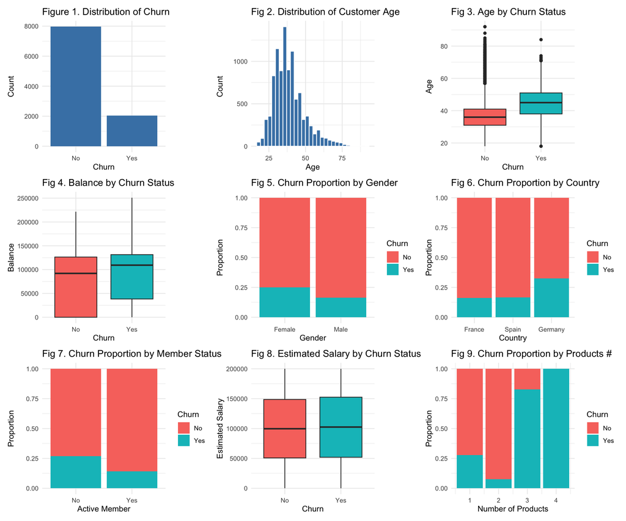

```
##   credit_score        age            tenure          balance
##  Min.   :350.0   Min.   :18.00   Min.   : 0.000   Min.   :     0
##  1st Qu.:584.0   1st Qu.:32.00   1st Qu.: 3.000   1st Qu.:     0
##  Median :652.0   Median :37.00   Median : 5.000   Median : 97199
##  Mean   :650.5   Mean   :38.92   Mean   : 5.013   Mean   : 76486
##  3rd Qu.:718.0   3rd Qu.:44.00   3rd Qu.: 7.000   3rd Qu.:127644
##  Max.   :850.0   Max.   :92.00   Max.   :10.000   Max.   :250898
##  products_number estimated_salary    churn      credit_card_Yes
##  Min.   :1.00    Min.   :    11.58   No :7963   Min.   :0.0000
##  1st Qu.:1.00    1st Qu.: 51002.11   Yes:2037   1st Qu.:0.0000
##  Median :1.00    Median :100193.91              Median :1.0000
##  Mean   :1.53    Mean   :100090.24              Mean   :0.7055
##  3rd Qu.:2.00    3rd Qu.:149388.25              3rd Qu.:1.0000
##  Max.   :4.00    Max.   :199992.48              Max.   :1.0000
##  active_member_Yes country_Spain    country_Germany   gender_Male
##  Min.   :0.0000    Min.   :0.0000   Min.   :0.0000   Min.   :0.0000
##  1st Qu.:0.0000    1st Qu.:0.0000   1st Qu.:0.0000   1st Qu.:0.0000
##  Median :1.0000    Median :0.0000   Median :0.0000   Median :1.0000
##  Mean   :0.5151    Mean   :0.2477   Mean   :0.2509   Mean   :0.5457
##  3rd Qu.:1.0000    3rd Qu.:0.0000   3rd Qu.:1.0000   3rd Qu.:1.0000
##  Max.   :1.0000    Max.   :1.0000   Max.   :1.0000   Max.   :1.0000
```

| min_credit_score | max_credit_score | min_age | max_age | min_tenure | max_tenure | min_balance | max_balance | min_products | max_products | min_salary | max_salary |
| --- | --- | --- | --- | --- | --- | --- | --- | --- | --- | --- | --- |
| 350 | 850 | 18 | 92 | 0 | 10 | 0 | 250898.1 | 1 | 4 | 11.58 | 199992.5 |

```
## [1] "Total Churn Values and Rates:"
```

```
##
##   No  Yes
## 7963 2037
```

```
##
##     No    Yes
## 0.7963 0.2037
```

```
## [1] "Churn Rates by Country:"
```

```
##
##                  No       Yes
##   France  0.8384523 0.1615477
##   Spain   0.8332660 0.1667340
##   Germany 0.6755680 0.3244320
```

```
## [1] "Churn Rates by Active Member Status:"
```

```
##
##              No       Yes
##   No  0.7314910 0.2685090
##   Yes 0.8573093 0.1426907
```

```
## [1] "Churn Rates and Total Values by Product Number:"
```

```
##
##             No        Yes
##   1 0.72285602 0.27714398
##   2 0.92418301 0.07581699
##   3 0.17293233 0.82706767
##   4 0.00000000 1.00000000
```

```
##
##       No  Yes
##   1 3675 1409
##   2 4242  348
##   3   46  220
##   4    0   60
```

## III. Model Development Process (15 points)

|  | credit_score | age | tenure | balance | products_number | estimated_salary | churn | credit_card_Yes | active_member_Yes | country_Spain | country_Germany | gender_Male |
| --- | --- | --- | --- | --- | --- | --- | --- | --- | --- | --- | --- | --- |
| 1 | 619 | 42 | 2 | 0.00 | 1 | 101348.88 | Yes | 1 | 1 | 0 | 0 | 0 |
| 2 | 608 | 41 | 1 | 83807.86 | 1 | 112542.58 | No | 0 | 1 | 1 | 0 | 0 |
| 3 | 502 | 42 | 8 | 159660.80 | 3 | 113931.57 | Yes | 1 | 0 | 0 | 0 | 0 |
| 4 | 699 | 39 | 1 | 0.00 | 2 | 93826.63 | No | 0 | 0 | 0 | 0 | 0 |
| 5 | 850 | 43 | 2 | 125510.82 | 1 | 79084.10 | No | 1 | 1 | 1 | 0 | 0 |
| 6 | 645 | 44 | 8 | 113755.78 | 2 | 149756.71 | Yes | 1 | 0 | 1 | 0 | 1 |

```
## 'data.frame':    10000 obs. of  12 variables:
##  $ credit_score     : int  619 608 502 699 850 645 822 376 501 684 ...
##  $ age              : int  42 41 42 39 43 44 50 29 44 27 ...
##  $ tenure           : int  2 1 8 1 2 8 7 4 4 2 ...
##  $ balance          : num  0 83808 159661 0 125511 ...
##  $ products_number  : int  1 1 3 2 1 2 2 4 2 1 ...
##  $ estimated_salary : num  101349 112543 113932 93827 79084 ...
##  $ churn            : Factor w/ 2 levels "No","Yes": 2 1 2 1 1 2 1 2 1 1 ...
##  $ credit_card_Yes  : int  1 0 1 0 1 1 1 1 0 1 ...
##  $ active_member_Yes: int  1 1 0 0 1 0 1 0 1 1 ...
##  $ country_Spain    : int  0 1 0 0 1 1 0 0 0 0 ...
##  $ country_Germany  : int  0 0 0 0 0 0 0 1 0 0 ...
##  $ gender_Male      : int  0 0 0 0 0 1 1 0 1 1 ...
```

```
## Train split: 70.01 %
```

```
## Test split:  29.99 %
```

```
## Train churn rate: 20.37 %
```

```
## Test churn rate: 20.37 %
```

We chose a logistic regression model as our model due to the nature of our data. More specifically, we selected our model using stepwise AIC variable selection over the full logistic regression model due to better performance on certain metrics.

```r
logit_full <- glm(churn ~ ., data=train, family="binomial")
summary(logit_full)
```

```
##
## Call:
## glm(formula = churn ~ ., family = "binomial", data = train)
##
## Coefficients:
##                     Estimate Std. Error z value Pr(>|z|)
## (Intercept)       -3.281e+00  2.943e-01 -11.147  < 2e-16 ***
## credit_score      -9.176e-04  3.361e-04  -2.730  0.00633 **
## age                7.435e-02  3.110e-03  23.909  < 2e-16 ***
## tenure            -1.312e-02  1.118e-02  -1.173  0.24069
## balance            3.446e-06  6.102e-07   5.647 1.63e-08 ***
## products_number   -6.968e-02  5.648e-02  -1.234  0.21726
## estimated_salary  -1.638e-07  5.613e-07  -0.292  0.77045
## credit_card_Yes   -7.038e-02  7.081e-02  -0.994  0.32025
## active_member_Yes -1.090e+00  6.911e-02 -15.766  < 2e-16 ***
## country_Spain      1.527e-02  8.440e-02   0.181  0.85646
## country_Germany    7.040e-01  8.094e-02   8.697  < 2e-16 ***
## gender_Male       -5.734e-01  6.534e-02  -8.775  < 2e-16 ***
## ---
## Signif. codes:  0 '***' 0.001 '**' 0.01 '*' 0.05 '.' 0.1 ' ' 1
##
## (Dispersion parameter for binomial family taken to be 1)
##
##     Null deviance: 7077.6  on 7000  degrees of freedom
## Residual deviance: 5969.4  on 6989  degrees of freedom
## AIC: 5993.4
##
## Number of Fisher Scoring iterations: 5
```

```r
logit_step <- stepAIC(logit_full, direction="both", trace=FALSE)
summary(logit_step)
```

```
##
## Call:
## glm(formula = churn ~ credit_score + age + balance + active_member_Yes +
##     country_Germany + gender_Male, family = "binomial", data = train)
##
## Coefficients:
##                     Estimate Std. Error z value Pr(>|z|)
## (Intercept)       -3.540e+00  2.586e-01 -13.692  < 2e-16 ***
## credit_score      -9.058e-04  3.359e-04  -2.697    0.007 **
## age                7.451e-02  3.107e-03  23.984  < 2e-16 ***
## balance            3.669e-06  5.871e-07   6.249 4.12e-10 ***
## active_member_Yes -1.088e+00  6.904e-02 -15.758  < 2e-16 ***
## country_Germany    6.846e-01  7.530e-02   9.092  < 2e-16 ***
## gender_Male       -5.733e-01  6.527e-02  -8.784  < 2e-16 ***
## ---
## Signif. codes:  0 '***' 0.001 '**' 0.01 '*' 0.05 '.' 0.1 ' ' 1
##
## (Dispersion parameter for binomial family taken to be 1)
##
##     Null deviance: 7077.6  on 7000  degrees of freedom
## Residual deviance: 5973.5  on 6994  degrees of freedom
## AIC: 5987.5
##
## Number of Fisher Scoring iterations: 5
```

The final stepwise logistic regression model retained credit_score, age, balance, active_member_Yes, country_Germany, and gender as predictors of churn. Age, balance, active membership, being located in Germany, and gender were significant at the 5% level. Older customers and customers with higher account balances exhibited higher odds of churn, while active members and male customers exhibited lower odds of churn. Customers located in Germany were significantly more likely to churn than customers in the reference country. The final model reduced deviance substantially relative to the null model, indicating that the retained predictors provide meaningful explanatory power. The model substantially improved fit relative to the intercept-only model, reducing deviance from 7077.6 to 5973.5.

```r
# Compute odds ratios
exp(coef(logit_step))
```

```
##       (Intercept)      credit_score               age           balance
##        0.02900177        0.99909466        1.07735645        1.00000367
## active_member_Yes   country_Germany       gender_Male
##        0.33689204        1.98300666        0.56365751
```

```r
# 95% CI for predictors
exp(confint(logit_step))
```

```
##                        2.5 %     97.5 %
## (Intercept)       0.01742474 0.04802264
## credit_score      0.99843671 0.99975225
## age               1.07085671 1.08398010
## balance           1.00000252 1.00000482
## active_member_Yes 0.29401278 0.38541689
## country_Germany   1.71097025 2.29855579
## gender_Male       0.49583848 0.64043400
```

Compute VIF to check for multicollinearity:

```r
vif(logit_step)
```

```
##      credit_score               age           balance active_member_Yes
##          1.000811          1.085746          1.186767          1.079263
##   country_Germany       gender_Male
##          1.184501          1.003899
```

All VIF values are close to 1, with the highest value equal to 1.187 for balance. These results indicate no evidence of problematic multicollinearity, suggesting that the coefficient estimates are stable and interpretable (James et al. 2014).

First we will perform any metric calculations that are not dependent on a prediction threshold cutoff. We check the Brier score (MSE), RMSE, SSE as follows:

```
##                                 Brier Score (MSE)      RMSE     SSE
## Probability Calibration Metrics         0.1350271 0.3674604 945.325
```

The logistic regression model had a Brier score of 0.135, which suggests that on average, the model’s predicted probabilities deviate from the true outcomes by a modest amount (n.d.). The corresponding RMSE of 0.367 also reflects moderate prediction error on the probability scale. The SSE was 945.325. However, this metric is scale-dependent and less informative than the two other metrics (James et al. 2014).

Compute the pseudo-$R^2$:

```
## fitting null model for pseudo-r2
```

```
##           llh       llhNull            G2      McFadden          r2ML
## -2986.7518470 -3538.7879986  1104.0723031     0.1559958     0.1458958
##          r2CU
##     0.2293518
```

The final logistic regression model achieved a McFadden pseudo-$R^2$ of 0.156, indicating a meaningful improvement in fit relative to the intercept-only model. Although pseudo-$R^2$ values in logistic regression are not interpreted the same way as ordinary pseudo-$R^2$ in linear regression, this result suggests that the selected predictors provide a moderate and useful level of explanatory power for customer churn (Long 1997).

Next, we perform a Hosmer-Lemeshow goodness-of-fit test:

**Hypotheses**:
$$H_0: \text{model fits the data well}\\$$
$$H_a: \text{model does not fit the data well}$$

**Decision rule**: At the 5% significance level, if p < 0.05, then reject $H_0$. Otherwise, fail to reject $H_0$.

```
##
##  Hosmer and Lemeshow goodness of fit (GOF) test
##
## data:  actual_numeric, probs_logit
## X-squared = 9.9436, df = 8, p-value = 0.269
```

**Conclusion**: At the 5% significance level, since the p-value is greater than 0.05, we fail to reject $H_0$. There is sufficient evidence to suggest the model fits the data well (Hosmer and Lemeshow 2000).

We first check the ROC curve and AUC (Fawcett 2006) before deciding which cutoff to choose:

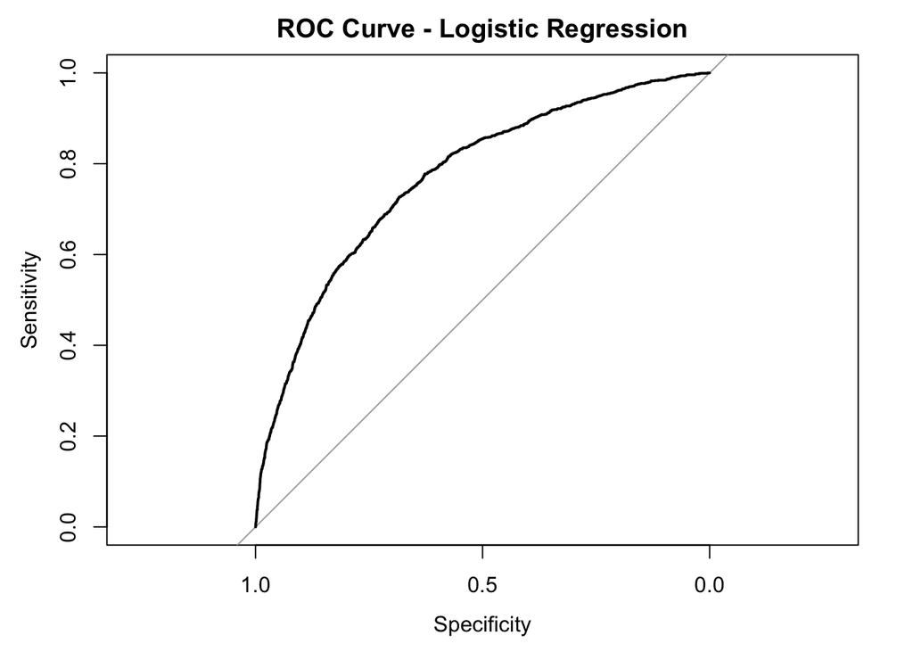

```
## Area under the curve: 0.7688
```

Finally, we actually try predicting churns two options by introducing a decision rule cutoff(Kennedy 2024). To determine what cutoff seems best - and if deviating from the trivial choice 0.5 is useful at all - one may build a function for simulation purposes.

Key Cutoff Selection Metrics for the Final Logistic Regression Model

| Cutoff | TN | FP | FN | TP | Accuracy | Sensitivity | Specificity | Precision | Recall | F1 | Balanced_Accuracy |
| --- | --- | --- | --- | --- | --- | --- | --- | --- | --- | --- | --- |
| 0.50 | 5373 | 202 | 1115 | 311 | 0.8119 | 0.2181 | 0.9638 | 0.6062 | 0.2181 | 0.3208 | 0.5909 |
| 0.45 | 5276 | 299 | 1036 | 390 | 0.8093 | 0.2735 | 0.9464 | 0.5660 | 0.2735 | 0.3688 | 0.6099 |
| 0.40 | 5152 | 423 | 939 | 487 | 0.8055 | 0.3415 | 0.9241 | 0.5352 | 0.3415 | 0.4170 | 0.6328 |
| 0.35 | 4987 | 588 | 826 | 600 | 0.7980 | 0.4208 | 0.8945 | 0.5051 | 0.4208 | 0.4591 | 0.6576 |
| 0.30 | 4750 | 825 | 696 | 730 | 0.7827 | 0.5119 | 0.8520 | 0.4695 | 0.5119 | 0.4898 | 0.6820 |

Among the tested probability cutoffs, 0.35 provided the best overall balance between identifying churners and controlling false positives. While the 0.30 cutoff achieved the highest sensitivity, F1 score, and balanced accuracy, it also generated substantially more false positives and a lower precision rate. The 0.35 cutoff offered a stronger compromise, improving sensitivity meaningfully over 0.40 and 0.50 while maintaining better specificity and precision than 0.30. For this reason, 0.35 was selected as the final operational cutoff for the logistic regression model. Going forward, we will therefore only analyze that model:

```
## Confusion Matrix and Statistics
##
##           Reference
## Prediction   No  Yes
##        No  4987  826
##        Yes  588  600
##
##                Accuracy : 0.798
##                  95% CI : (0.7884, 0.8074)
##     No Information Rate : 0.7963
##     P-Value [Acc > NIR] : 0.3674
##
##                   Kappa : 0.3362
##
##  Mcnemar's Test P-Value : 2.926e-10
##
##               Precision : 0.5051
##                  Recall : 0.4208
##                      F1 : 0.4591
##              Prevalence : 0.2037
##          Detection Rate : 0.0857
##    Detection Prevalence : 0.1697
##       Balanced Accuracy : 0.6576
##
##        'Positive' Class : Yes
##
```

Transposed Final Summary Metrics for the Logistic Regression Model on Train Data at a 0.35 Cutoff

| Metric | Logistic Regression (0.35 cutoff) |
| --- | --- |
| TN | 4987 |
| FP | 588 |
| FN | 826 |
| TP | 600 |
| Accuracy | 0.7980 |
| Kappa | 0.3362 |
| Sensitivity | 0.4208 |
| Specificity | 0.8945 |
| Precision | 0.5051 |
| Recall | 0.4208 |
| F1 | 0.4591 |
| NPV | 0.8579 |
| Prevalence | 0.2037 |
| Detection Rate | 0.0857 |
| Detection Prevalence | 0.1697 |
| Balanced Accuracy | 0.6576 |
| AUC | 0.7688 |
| SSE | 945.3250 |
| RMSE | 0.3675 |

## IV. Model Performance Testing (15 points)

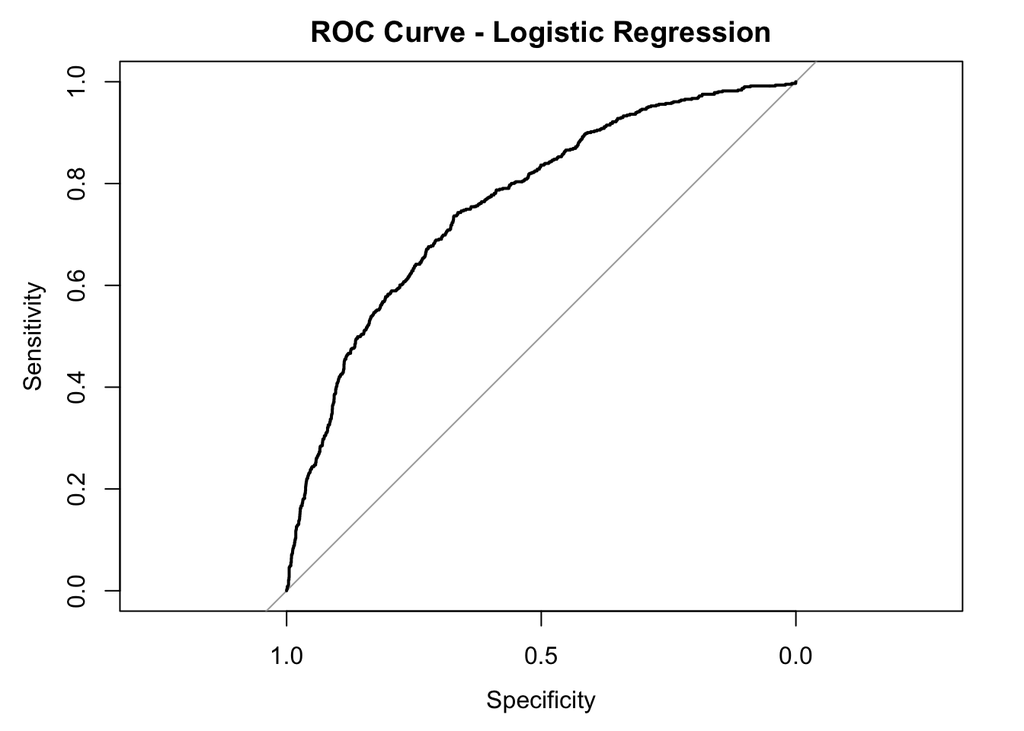

```
## Area under the curve: 0.7624
```

The model achieved an AUC of 0.7624, meaning that in approximately 76.24% of randomly selected churner versus non-churner pairs, the model assigns a higher predicted probability to the churner (Fawcett 2006). This indicates moderate discriminatory ability. While the model provides useful separation between customers who churn and those who do not, its ranking performance is only fair to acceptable rather than strong.

```
## Confusion Matrix and Statistics
##
##           Reference
## Prediction   No  Yes
##        No  2119  345
##        Yes  269  266
##
##                Accuracy : 0.7953
##                  95% CI : (0.7804, 0.8096)
##     No Information Rate : 0.7963
##     P-Value [Acc > NIR] : 0.564755
##
##                   Kappa : 0.3384
##
##  Mcnemar's Test P-Value : 0.002472
##
##               Precision : 0.4972
##                  Recall : 0.4354
##                      F1 : 0.4642
##              Prevalence : 0.2037
##          Detection Rate : 0.0887
##    Detection Prevalence : 0.1784
##       Balanced Accuracy : 0.6614
##
##        'Positive' Class : Yes
##
```

Transposed Final Summary Metrics for the Logistic Regression Model on Test Data at a 0.35 Cutoff

| Metric | Logistic Regression (0.35 cutoff) |
| --- | --- |
| TN | 2119 |
| FP | 269 |
| FN | 345 |
| TP | 266 |
| Accuracy | 0.7953 |
| Kappa | 0.3384 |
| Sensitivity | 0.4354 |
| Specificity | 0.8874 |
| Precision | 0.4972 |
| Recall | 0.4354 |
| F1 | 0.4642 |
| NPV | 0.8600 |
| Prevalence | 0.2037 |
| Detection Rate | 0.0887 |
| Detection Prevalence | 0.1784 |
| Balanced Accuracy | 0.6614 |
| AUC | 0.7624 |
| SSE | 413.8020 |
| RMSE | 0.3715 |

|  | Brier.score..MSE. | RMSE | SSE | Accuracy | Precision | Recall | F1.score | AUC |
| --- | --- | --- | --- | --- | --- | --- | --- | --- |
| Logistic Train | 0.1350271 | 0.3674604 | 945.325 | 0.7980289 | 0.5050505 | 0.4207574 | 0.4590666 | 0.7688432 |
| Logistic Test | 0.1379800 | 0.3714566 | 413.802 | 0.7952651 | 0.4971963 | 0.4353519 | 0.4642234 | 0.7623747 |

The logistic regression model showed similar performance on the train and test sets, which indicates the model generalizes well and that there is no evidence of overfitting. Brier score and RMSE increased only slightly from the train to test set, and classification metrics (accuracy, precision, recall, F1) were roughly the same. The model demonstrates moderate predictive performance on both sets, though it has limited ability to detect churners likely due to the class imbalance.

## V. Challenger Models (15 points)

We use `bank_factor`, our factored dataset from earlier for these models.

|  | credit_score | country | gender | age | tenure | balance | products_number | credit_card | active_member | estimated_salary | churn |
| --- | --- | --- | --- | --- | --- | --- | --- | --- | --- | --- | --- |
| 1 | 619 | France | Female | 42 | 2 | 0.00 | 1 | Yes | Yes | 101348.88 | Yes |
| 2 | 608 | Spain | Female | 41 | 1 | 83807.86 | 1 | No | Yes | 112542.58 | No |
| 3 | 502 | France | Female | 42 | 8 | 159660.80 | 3 | Yes | No | 113931.57 | Yes |
| 4 | 699 | France | Female | 39 | 1 | 0.00 | 2 | No | No | 93826.63 | No |
| 5 | 850 | Spain | Female | 43 | 2 | 125510.82 | 1 | Yes | Yes | 79084.10 | No |
| 6 | 645 | Spain | Male | 44 | 8 | 113755.78 | 2 | Yes | No | 149756.71 | Yes |

```
## 'data.frame':    10000 obs. of  11 variables:
##  $ credit_score    : int  619 608 502 699 850 645 822 376 501 684 ...
##  $ country         : Factor w/ 3 levels "France","Spain",..: 1 2 1 1 2 2 1 3 1 1 ...
##  $ gender          : Factor w/ 2 levels "Female","Male": 1 1 1 1 1 2 2 1 2 2 ...
##  $ age             : int  42 41 42 39 43 44 50 29 44 27 ...
##  $ tenure          : int  2 1 8 1 2 8 7 4 4 2 ...
##  $ balance         : num  0 83808 159661 0 125511 ...
##  $ products_number : int  1 1 3 2 1 2 2 4 2 1 ...
##  $ credit_card     : Factor w/ 2 levels "No","Yes": 2 1 2 1 2 2 2 2 1 2 ...
##  $ active_member   : Factor w/ 2 levels "No","Yes": 2 2 1 1 2 1 2 1 2 2 ...
##  $ estimated_salary: num  101349 112543 113932 93827 79084 ...
##  $ churn           : Factor w/ 2 levels "No","Yes": 2 1 2 1 1 2 1 2 1 1 ...
```

```
## Train split: 70.01 %
```

```
## Test split:  29.99 %
```

```
## Train churn rate: 20.4 %
```

```
## Test churn rate: 20.4 %
```

### Challenger 1: Boosted C5.0 Tree

The first challenger model we build is a Boosted C5.0 model (Perner 2018).

```
##
## Call:
## C5.0.formula(formula = churn ~ ., data = train_factor, trials = 25, type
##  = "prob")
##
## Classification Tree
## Number of samples: 7001
## Number of predictors: 10
##
## Number of boosting iterations: 25
## Average tree size: 22.2
##
## Non-standard options: attempt to group attributes
```

We test different probability cutoffs and analyze metrics for each (Kennedy 2024):

Testing Probability Cutoffs from 0.3 to 0.5 for C5.0 Boosted Model

| Cutoff | TN | FP | FN | TP | Accuracy | Sensitivity | Specificity | Precision | Recall | F1 | Balanced_Accuracy |
| --- | --- | --- | --- | --- | --- | --- | --- | --- | --- | --- | --- |
| 0.50 | 5458 | 117 | 662 | 764 | 0.8887 | 0.5358 | 0.9790 | 0.8672 | 0.5358 | 0.6623 | 0.76 |
| 0.45 | 5390 | 185 | 596 | 830 | 0.8884 | 0.5820 | 0.9668 | 0.8177 | 0.5820 | 0.6800 | 0.77 |
| 0.40 | 5311 | 264 | 539 | 887 | 0.8853 | 0.6220 | 0.9526 | 0.7706 | 0.6220 | 0.6884 | 0.79 |
| 0.35 | 5197 | 378 | 478 | 948 | 0.8777 | 0.6648 | 0.9322 | 0.7149 | 0.6648 | 0.6890 | 0.80 |
| 0.30 | 5068 | 507 | 406 | 1020 | 0.8696 | 0.7153 | 0.9091 | 0.6680 | 0.7153 | 0.6908 | 0.81 |

While a cutoff of 0.30 achieves the highest recall it results in a large number of false positives and lower precision, which is less desirable. The **0.35** cutoff (consistent with the logistic regression model) maintains strong recall while significantly improving precision and reducing false positives. Strong recall is important when considering identifying customer churn for this bank. This cutoff also results in high overall performance metrics such as F1 score and balanced accuracy.

Evaluate model on train data:

```
##                   Boosted C5.0 Train
## Brier score (MSE)            0.08749
## RMSE                         0.29579
## SSE                        612.51083
```

```
## Confusion Matrix and Statistics
##
##           Reference
## Prediction   No  Yes
##        No  5197  478
##        Yes  378  948
##
##                Accuracy : 0.8777
##                  95% CI : (0.8698, 0.8853)
##     No Information Rate : 0.7963
##     P-Value [Acc > NIR] : < 2.2e-16
##
##                   Kappa : 0.613
##
##  Mcnemar's Test P-Value : 0.000715
##
##               Precision : 0.7149
##                  Recall : 0.6648
##                      F1 : 0.6890
##              Prevalence : 0.2037
##          Detection Rate : 0.1354
##    Detection Prevalence : 0.1894
##       Balanced Accuracy : 0.7985
##
##        'Positive' Class : Yes
##
```

The C5.0 boosted model showed strong in-sample performance with an accuracy of 87.77%, which is substantially higher than the no-information rate of 79.63%. Precision (71.49%), recall (66.48%), and F1-score (68.9%) showed good ability to identify churners, and the balanced accuracy of 79.85% suggests solid performance across both classes. In terms of probability metrics, the boosted C5.0 model also achieves a lower Brier score and RMSE, which indicates more accurate probability predictions than the logistic regression model (n.d.). The boosted C5.0 model substantially outperforms logistic regression on the training set, though we must assess test set performance in case there is overfitting.

Evaluate model on test data:

```
## Confusion Matrix and Statistics
##
##           Reference
## Prediction   No  Yes
##        No  2157  228
##        Yes  231  383
##
##                Accuracy : 0.8469
##                  95% CI : (0.8336, 0.8597)
##     No Information Rate : 0.7963
##     P-Value [Acc > NIR] : 6.052e-13
##
##                   Kappa : 0.5291
##
##  Mcnemar's Test P-Value : 0.9256
##
##               Precision : 0.6238
##                  Recall : 0.6268
##                      F1 : 0.6253
##              Prevalence : 0.2037
##          Detection Rate : 0.1277
##    Detection Prevalence : 0.2047
##       Balanced Accuracy : 0.7651
##
##        'Positive' Class : Yes
##
```

|  | Brier.score..MSE. | RMSE | SSE | Accuracy | Precision | Recall | F1.score | AUC |
| --- | --- | --- | --- | --- | --- | --- | --- | --- |
| Boosted C5.0 Train | 0.08748905 | 0.2957855 | 612.5108 | 0.8777318 | 0.7149321 | 0.6647966 | 0.6889535 | 0.9030779 |
| Boosted C5.0 Test | 0.10333571 | 0.3214587 | 309.9038 | 0.8469490 | 0.6237785 | 0.6268412 | 0.6253061 | 0.8629238 |

The boosted C5.0 model demonstrated strong performance, though some overfitting is evident. The Brier score increased from the train to test set, meaning there was a decline in the probability prediction accuracy. Similarly, the accuracy decreased from 87.8% to 84.7% in the test set. The precision, recall, and F1 scores were also slightly lower when evaluated on the test set. Despite this performance drop, however, the model still achieves relatively strong test performance compared to logistic regression, so we can assume this model has good predictive ability and minimal overfitting.

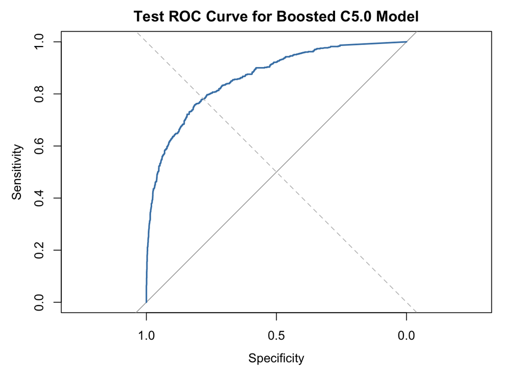

```
## Area under the curve: 0.8629
```

The model had a small drop in AUC from 0.90 in the train set to 0.86 in the test set which indicates minimal overfitting and good generalization (Fawcett 2006).

### Challenger 2: Random Forest

A random forest extends the decision tree by averaging predictions across 500 trees, each trained on a bootstrap sample with a random subset of predictors at each split. This reduces variance and produces a more stable, higher-performing classifier. OOB error provides an unbiased estimate of generalization error without needing a separate validation set (Perner 2018).

```
##
## Call:
##  randomForest(formula = churn ~ credit_score + country + gender +      age + balance + products_number + credit_card + active_member,      data = train_factor, ntree = 500, mtry = 3, classwt = c(No = 1,          Yes = 4), importance = TRUE)
##                Type of random forest: classification
##                      Number of trees: 500
## No. of variables tried at each split: 3
##
##         OOB estimate of  error rate: 16.1%
## Confusion matrix:
##       No Yes class.error
## No  5066 509  0.09130045
## Yes  618 808  0.43338008
```

The Random Forest model achieved an out-of-bag (OOB) error rate of 16.1%, which indicates good overall predictive performance. However, the confusion matrix shows an imbalance in classification performance, with a lower error rate for non-churners (9.1%) and a high error rate for churners (43.3%).

We applied class weights (`No = 1`, `Yes = 4`) to penalize misclassification of churners more heavily. While this shifts the model’s focus toward the minority class, the relatively high error rate for churners suggests that imbalance remains an issue.

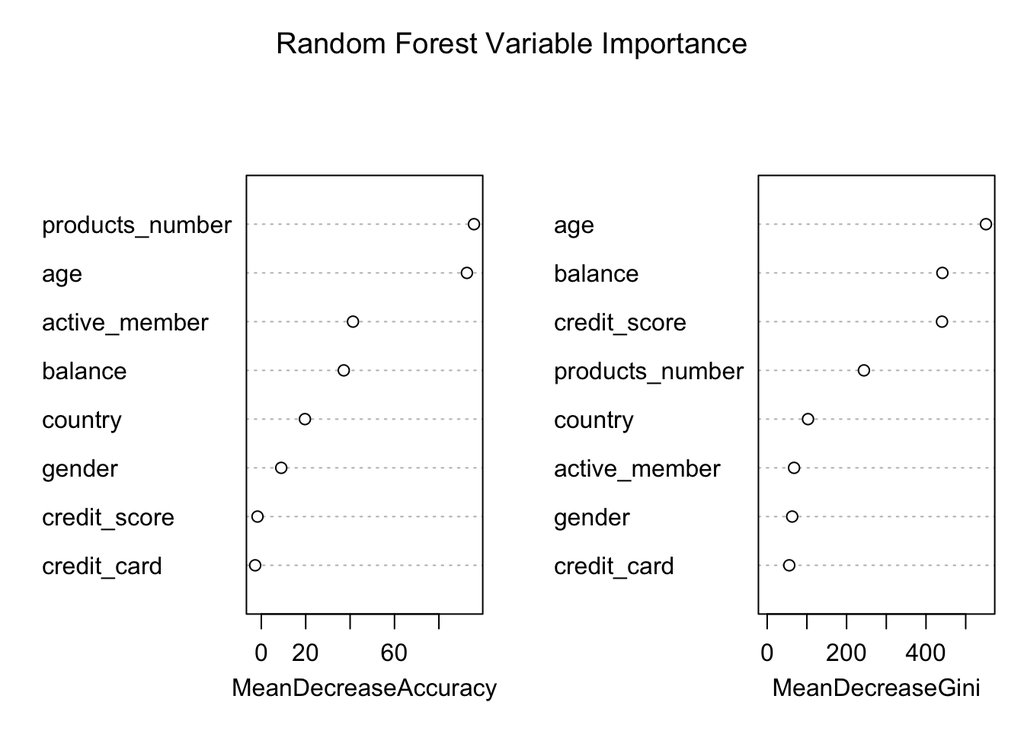

The variable importance plot shows that age and products_number are the most important based on Mean Decrease Accuracy, meaning they have a strong impact on model performance. Based on Mean Decrease Gini, age, balance, and credit_score are the most important, which suggests they are frequently used in tree splits.

Evaluate train set performance:

```
## Confusion Matrix and Statistics
##
##           Reference
## Prediction   No  Yes
##        No  5444    0
##        Yes  131 1426
##
##                Accuracy : 0.9813
##                  95% CI : (0.9778, 0.9843)
##     No Information Rate : 0.7963
##     P-Value [Acc > NIR] : < 2.2e-16
##
##                   Kappa : 0.9442
##
##  Mcnemar's Test P-Value : < 2.2e-16
##
##               Precision : 0.9159
##                  Recall : 1.0000
##                      F1 : 0.9561
##              Prevalence : 0.2037
##          Detection Rate : 0.2037
##    Detection Prevalence : 0.2224
##       Balanced Accuracy : 0.9883
##
##        'Positive' Class : Yes
##
```

Evaluate test set performance:

```
## Confusion Matrix and Statistics
##
##           Reference
## Prediction   No  Yes
##        No  2143  220
##        Yes  245  391
##
##                Accuracy : 0.8449
##                  95% CI : (0.8315, 0.8577)
##     No Information Rate : 0.7963
##     P-Value [Acc > NIR] : 4.804e-12
##
##                   Kappa : 0.5293
##
##  Mcnemar's Test P-Value : 0.2657
##
##               Precision : 0.6148
##                  Recall : 0.6399
##                      F1 : 0.6271
##              Prevalence : 0.2037
##          Detection Rate : 0.1304
##    Detection Prevalence : 0.2121
##       Balanced Accuracy : 0.7687
##
##        'Positive' Class : Yes
##
```

|  | Brier.score..MSE. | RMSE | SSE | Accuracy | Precision | Recall | F1.score | AUC |
| --- | --- | --- | --- | --- | --- | --- | --- | --- |
| Random Forest Train | 0.03869209 | 0.1967031 | 270.8833 | 0.9812884 | 0.9158638 | 1.0000000 | 0.9560845 | 0.9994450 |
| Random Forest Test | 0.11659950 | 0.3414667 | 349.6819 | 0.8449483 | 0.6147799 | 0.6399345 | 0.6271051 | 0.8577565 |

**ROC Curve Comparison on Test Data**

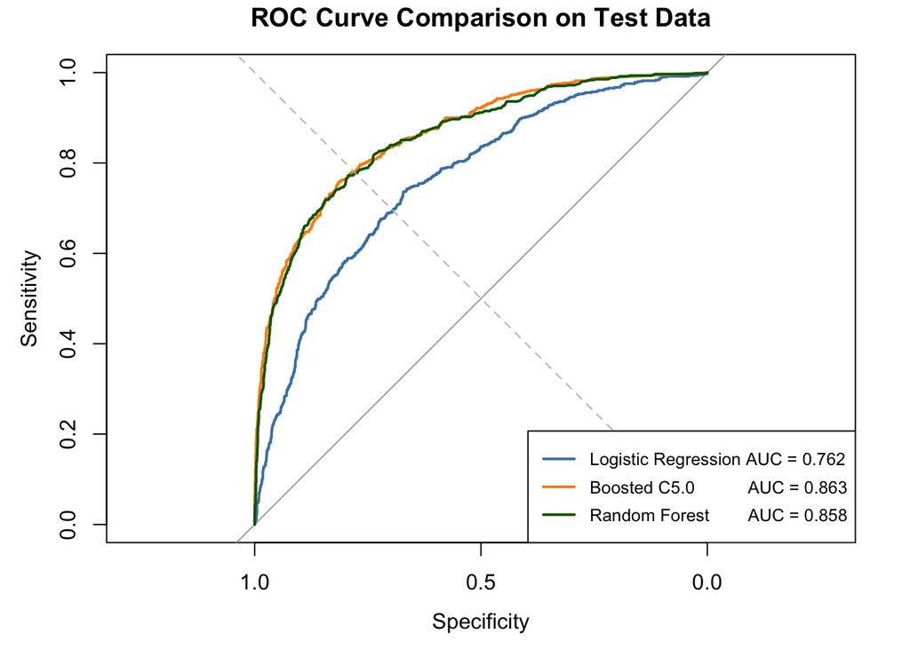

**Model Comparison Table**

Out of Sample Model Performance Comparison

| Model | Accuracy | Sensitivity | Specificity | Precision | Recall | F1.Score | AUC | MSE | RMSE |
| --- | --- | --- | --- | --- | --- | --- | --- | --- | --- |
| Logistic Regression | 0.7953 | 0.4354 | 0.8874 | 0.4972 | 0.4354 | 0.4642 | 0.7624 | 0.1380 | 0.3715 |
| Boosted C5.0 | 0.8469 | 0.6268 | 0.9033 | 0.6238 | 0.6268 | 0.6253 | 0.8629 | 0.1033 | 0.3215 |
| Random Forest | 0.8449 | 0.6399 | 0.8974 | 0.6148 | 0.6399 | 0.6271 | 0.8578 | 0.1166 | 0.3415 |

Given the class imbalance in the dataset (~20% churn), we applied different strategies across the models to improve detection of the minority class. Logistic regression addresses class imbalance through threshold tuning, whereas random forest incorporates class weighting during training, leading to improved detection of churners. The Boosted C5.0 model is inherently less sensitive to class imbalance, but we also used threshold adjustments to improve this model (Kennedy 2024).

## VI. Model Limitations and Assumptions (15 points)

### 6.2 Logistic Regression Assumptions

#### 6.2.1 Assessment of Assumptions

Logistic Regression Assumption Assessment

[output not shown]

#### 6.2.2 Box-Tidwell Test

The Box-Tidwell test checks whether the log-odds relationship is truly linear in continuous predictors. A significant interaction term (variable x log(variable)) signals non-linearity.

```
##
## Call:
## glm(formula = churn_num ~ age + age_log + balance + bal_log +
##     credit_score + cs_log, family = binomial, data = train_bt)
##
## Coefficients:
##                Estimate Std. Error z value Pr(>|z|)
## (Intercept)  -1.149e+01  2.268e+00  -5.069    4e-07 ***
## age           1.395e+00  1.029e-01  13.553   <2e-16 ***
## age_log      -2.753e-01  2.123e-02 -12.964   <2e-16 ***
## balance       4.351e-05  1.694e-05   2.568   0.0102 *
## bal_log      -3.218e-06  1.423e-06  -2.262   0.0237 *
## credit_score -5.724e-02  2.434e-02  -2.352   0.0187 *
## cs_log        7.560e-03  3.263e-03   2.317   0.0205 *
## ---
## Signif. codes:  0 '***' 0.001 '**' 0.01 '*' 0.05 '.' 0.1 ' ' 1
##
## (Dispersion parameter for binomial family taken to be 1)
##
##     Null deviance: 7077.6  on 7000  degrees of freedom
## Residual deviance: 6201.5  on 6994  degrees of freedom
## AIC: 6215.5
##
## Number of Fisher Scoring iterations: 5
```

The Box-Tidwell test results indicate that the interaction terms for age, balance, and credit score are statistically significant, which suggests these predictors do not have a linear relationship with the log-odds of churn. This violates the linearity assumption of logistic regression. Transformations or polynomial terms are worth exploring in future models (Leung 2021).

### 6.3 Residuals and Normality

For logistic regression, residuals are not required to be normally distributed — this is an OLS assumption that does not apply here. For random forest there are no distributional assumptions at all (Perner 2018).

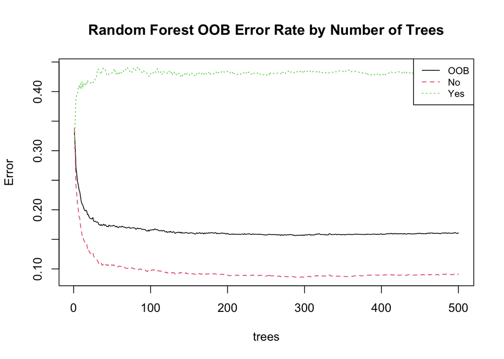

Random Forest OOB Error Rate

OOB error stabilizes ~50 trees. 500 trees are more than sufficient, so there is no benefit beyond this amount. While the overall OOB error rate is relatively low (~15%), the class-specific error rates show that the model performs much better for non-churners than for churners. In particular, the error rate for churners remains high at ~43%, which suggests the model struggles more to identify the minority class.

### 6.4 Tree-Based Ensemble Model Assumptions

The Boosted C5.0 and Random Forest are flexible and have no strict assumptions on linearity or functional form, but they require careful tuning and evaluation to avoid overfitting and handle class imbalance. These were addressed during our challenger model development through class weighting and threshold tuning (James et al. 2014; Kennedy 2024).

### 6.5 Pseudo R^2, SSE and RMSE Summary

Goodness-of-Fit Summary — All Models

| Metric | Logistic | Boosted.C5.0 | Random.Forest |
| --- | --- | --- | --- |
| McFadden Pseudo R^2 | 0.1560 | NA | NA |
| MSE (test) | 0.1380 | 0.1033 | 0.1166 |
| RMSE (test) | 0.3715 | 0.3215 | 0.3415 |
| AUC (test) | 0.7624 | 0.8629 | 0.8578 |

Pseudo-$R^2$ (only for logistic regression) estimates the goodness-of-fit by comparing the log-likelihood of a full model against an intercept-only model and typically ranges from 0 to 1. Higher values suggest better fit, with values greater than 0.20 considered as excellent (Long 1997). Lower MSE (Brier score) and RMSE indicate better probability calibration (n.d.).

### 6.6 Known Limitations

**Random Forest:** (Perner 2018)

- Black-box: cannot explain individual predictions to customers or regulators
- Required class weight correction due to 80/20 class imbalance, without this model predicted almost all “No”
- Cannot extend beyond the range of the training data

**Boosted C5.0:** (Perner 2018)

- Boosted models may be susceptible to overfitting
- Unlike logistic regression, boosted trees do not have simple, easily interpretable relationships (e.g., odds ratios), which makes them harder to explain in a business/regulatory context
- Even if overall performance is strong, the model can still exhibit sensitivity to class imbalance

**Dataset:**

- Static cross-sectional snapshot, no time-series features like balance trend or transaction frequency
- No information on competitor offers or macroeconomic conditions that may independently drive churn

## VII. Ongoing Model Monitoring Plan (5 points)

A deployed churn model operates in a live environment where customer behavior, economic conditions, and bank product offerings continuously evolve. Without active monitoring, a model that performs well today can silently degrade and produce misleading scores (Sobolik and Boudard 2024).

### 7.1 Quantitative Monitoring Thresholds

Model Monitoring Thresholds and Triggers

[output not shown]

Thresholds were set relative to our actual test results: AUC baseline 0.8629, accuracy baseline 0.8469.

### 7.2 Monitoring Assumptions

The model assumes the following conditions remain stable during deployment:

1. **Stable predictor distributions** — age, balance, and other inputs do not shift materially. Monitored via PSI, where PSI > 0.20 signals significant population shift requiring retraining.
2. **Consistent data pipeline** — input data continues to be formatted identically to training data. Any upstream schema changes must trigger an immediate model review.
3. **Stable churn definition** — the business definition of churn remains unchanged. Redefining churn invalidates the model entirely.
4. **No structural breaks** — major economic shocks, regulatory changes, or bank mergers may fundamentally alter customer behavior in ways the model cannot anticipate.

### 7.3 Model Replacement Triggers

The model should be retired and fully rebuilt when any of the following occur:

- AUC falls below 0.75 on two consecutive monthly monitoring samples
- PSI exceeds 0.25 for two consecutive periods
- A regulatory requirement mandates a different modeling approach
- A challenger model demonstrates materially superior performance in a scheduled annual evaluation

## VIII. Conclusion (5 points)

We chose the Boosted C5.0 model based on its test performance and stability compared to its training performance. It achieved the highest AUC (0.8629), accuracy (0.8469), and the lowest prediction error (MSE and RMSE), which indicates strong discrimination and well-calibrated probabilities. While Random Forest showed comparable performance and slightly higher recall on the test set, it exhibited greater overfitting and weaker probability calibration, making it less robust overall. Logistic regression, although more interpretable, performed substantially worse across all metrics, so its predictive capability was not comparable to the other two models. Given the objective of accurately identifying customers at risk of churn, we select the Boosted model as the champion model since it provides the best balance of predictive performance and generalizability.

## Bibliography (7 points)

n.d. *Library.virginia.edu*. https://library.virginia.edu/data/articles/a-brief-on-brier-scores.

Bobbitt, Zach. 2020. “The 6 Assumptions of Logistic Regression (with Examples).” *Statology*. https://www.statology.org/assumptions-of-logistic-regression/.

Fawcett, Tom. 2006. “An Introduction to ROC Analysis.” *Pattern Recognition Letters* 27 (8): 861–74. https://doi.org/https://doi.org/10.1016/j.patrec.2005.10.010.

Hosmer, David W., and Stanley. Lemeshow. 2000. *Applied Logistic Regression David w. Hosmer, Stanley Lemeshow.* 2nd ed. Wiley Series in Probability and Statistics. New York: Wiley.

James, Gareth, Daniela Witten, Trevor Hastie, and Robert Tibshirani. 2014. *An Introduction to Statistical Learning: With Applications in r*. Springer Publishing Company, Incorporated.

Kennedy, W Brett. 2024. “Achieve Better Classification Results with ClassificationThresholdTuner.” *Medium*. TDS Archive. https://medium.com/data-science/achieve-better-classification-results-with-classificationthresholdtuner-39c5d454637e.

Leung, Kenneth. 2021. “Assumptions of Logistic Regression, Clearly Explained.” *Medium*. TDS Archive. https://medium.com/data-science/assumptions-of-logistic-regression-clearly-explained-44d85a22b290.

Long, J. S. 1997. *Regression Models for Categorical and Limited Dependent Variables*. Thousand Oaks: Sage.

Perner, Petra, ed. 2018. *Machine Learning and Data Mining in Pattern Recognition: 14th International Conference, MLDM 2018, New York, NY, USA, July 15-19, 2018, Proceedings, Part II*. Berlin, Heidelberg: Springer-Verlag.

Sobolik, Thomas, and Léopold Boudard. 2024. “Machine Learning Model Monitoring: Best Practices.” *Datadog*. https://www.datadoghq.com/blog/ml-model-monitoring-in-production-best-practices/.

## Appendix (3 points)

**Confusion Matrices**

```
## [1] "Logistic Regression Train"
```

```
## Confusion Matrix and Statistics
##
##           Reference
## Prediction   No  Yes
##        No  4987  826
##        Yes  588  600
##
##                Accuracy : 0.798
##                  95% CI : (0.7884, 0.8074)
##     No Information Rate : 0.7963
##     P-Value [Acc > NIR] : 0.3674
##
##                   Kappa : 0.3362
##
##  Mcnemar's Test P-Value : 2.926e-10
##
##               Precision : 0.5051
##                  Recall : 0.4208
##                      F1 : 0.4591
##              Prevalence : 0.2037
##          Detection Rate : 0.0857
##    Detection Prevalence : 0.1697
##       Balanced Accuracy : 0.6576
##
##        'Positive' Class : Yes
##
```

```
## [1] "Logistic Regression Test"
```

```
## Confusion Matrix and Statistics
##
##           Reference
## Prediction   No  Yes
##        No  2119  345
##        Yes  269  266
##
##                Accuracy : 0.7953
##                  95% CI : (0.7804, 0.8096)
##     No Information Rate : 0.7963
##     P-Value [Acc > NIR] : 0.564755
##
##                   Kappa : 0.3384
##
##  Mcnemar's Test P-Value : 0.002472
##
##               Precision : 0.4972
##                  Recall : 0.4354
##                      F1 : 0.4642
##              Prevalence : 0.2037
##          Detection Rate : 0.0887
##    Detection Prevalence : 0.1784
##       Balanced Accuracy : 0.6614
##
##        'Positive' Class : Yes
##
```

```
## [1] "Boosted C5.0 Train"
```

```
## Confusion Matrix and Statistics
##
##           Reference
## Prediction   No  Yes
##        No  5197  478
##        Yes  378  948
##
##                Accuracy : 0.8777
##                  95% CI : (0.8698, 0.8853)
##     No Information Rate : 0.7963
##     P-Value [Acc > NIR] : < 2.2e-16
##
##                   Kappa : 0.613
##
##  Mcnemar's Test P-Value : 0.000715
##
##               Precision : 0.7149
##                  Recall : 0.6648
##                      F1 : 0.6890
##              Prevalence : 0.2037
##          Detection Rate : 0.1354
##    Detection Prevalence : 0.1894
##       Balanced Accuracy : 0.7985
##
##        'Positive' Class : Yes
##
```

```
## [1] "Boosted C5.0 Test"
```

```
## Confusion Matrix and Statistics
##
##           Reference
## Prediction   No  Yes
##        No  2157  228
##        Yes  231  383
##
##                Accuracy : 0.8469
##                  95% CI : (0.8336, 0.8597)
##     No Information Rate : 0.7963
##     P-Value [Acc > NIR] : 6.052e-13
##
##                   Kappa : 0.5291
##
##  Mcnemar's Test P-Value : 0.9256
##
##               Precision : 0.6238
##                  Recall : 0.6268
##                      F1 : 0.6253
##              Prevalence : 0.2037
##          Detection Rate : 0.1277
##    Detection Prevalence : 0.2047
##       Balanced Accuracy : 0.7651
##
##        'Positive' Class : Yes
##
```

```
## [1] "Random Forest Train"
```

```
## Confusion Matrix and Statistics
##
##           Reference
## Prediction   No  Yes
##        No  5444    0
##        Yes  131 1426
##
##                Accuracy : 0.9813
##                  95% CI : (0.9778, 0.9843)
##     No Information Rate : 0.7963
##     P-Value [Acc > NIR] : < 2.2e-16
##
##                   Kappa : 0.9442
##
##  Mcnemar's Test P-Value : < 2.2e-16
##
##               Precision : 0.9159
##                  Recall : 1.0000
##                      F1 : 0.9561
##              Prevalence : 0.2037
##          Detection Rate : 0.2037
##    Detection Prevalence : 0.2224
##       Balanced Accuracy : 0.9883
##
##        'Positive' Class : Yes
##
```

```
## [1] "Random Forest Test"
```

```
## Confusion Matrix and Statistics
##
##           Reference
## Prediction   No  Yes
##        No  2143  220
##        Yes  245  391
##
##                Accuracy : 0.8449
##                  95% CI : (0.8315, 0.8577)
##     No Information Rate : 0.7963
##     P-Value [Acc > NIR] : 4.804e-12
##
##                   Kappa : 0.5293
##
##  Mcnemar's Test P-Value : 0.2657
##
##               Precision : 0.6148
##                  Recall : 0.6399
##                      F1 : 0.6271
##              Prevalence : 0.2037
##          Detection Rate : 0.1304
##    Detection Prevalence : 0.2121
##       Balanced Accuracy : 0.7687
##
##        'Positive' Class : Yes
##
```

The confusion matrices compare each model’s predicted vs. actual churn classifications across train and test sets, highlighting Random Forest’s overfitting (near-perfect training accuracy that drops significantly on test data) and Logistic Regression’s more consistent generalization.

**ROC Curves**

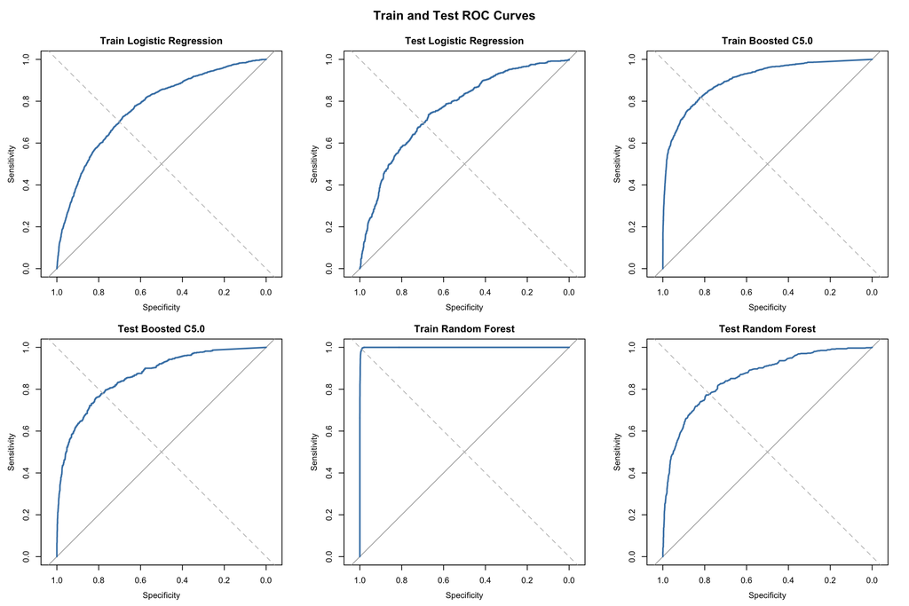

The six ROC curves display each model’s ability to distinguish between churned and non-churned customers across train and test sets, showing that Random Forest and Boosted C5.0 substantially outperform Logistic Regression, with the near-perfect Train Random Forest curve confirming overfitting to the training data.

**Additional Data Analysis Plots**

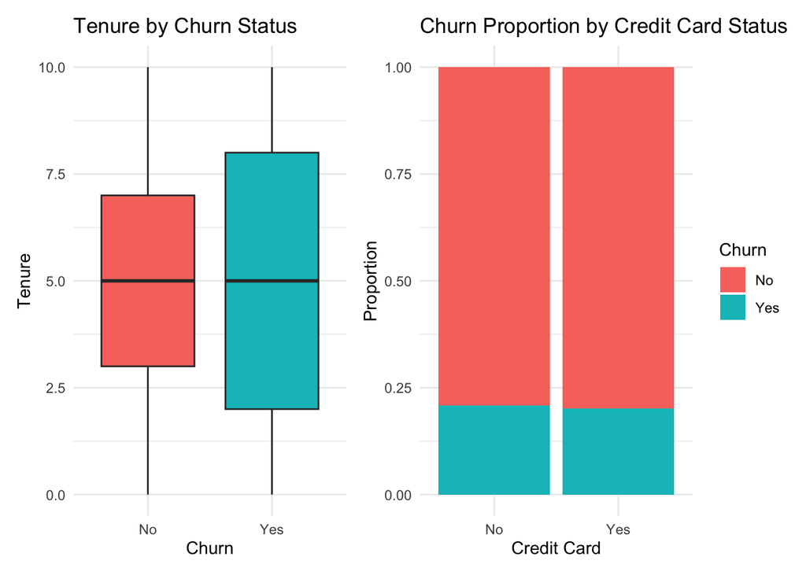

Churn Proportion by Credit Card Status (stacked bar): The churn rate is nearly identical between customers with and without a credit card (~20% each), indicating that credit card ownership has little to no predictive power for churn

**Aggregated Model Metrics**

|  | Brier.score..MSE. | RMSE | SSE | Accuracy | Precision | Recall | F1.score | AUC |
| --- | --- | --- | --- | --- | --- | --- | --- | --- |
| Logistic Train | 0.1350 | 0.3675 | 945.3250 | 0.7980 | 0.5051 | 0.4208 | 0.4591 | 0.7688 |
| Logistic Test | 0.1380 | 0.3715 | 413.8020 | 0.7953 | 0.4972 | 0.4354 | 0.4642 | 0.7624 |
| Boosted C5.0 Train | 0.0875 | 0.2958 | 612.5108 | 0.8777 | 0.7149 | 0.6648 | 0.6890 | 0.9031 |
| Boosted C5.0 Test | 0.1033 | 0.3215 | 309.9038 | 0.8469 | 0.6238 | 0.6268 | 0.6253 | 0.8629 |
| Random Forest Train | 0.0387 | 0.1967 | 270.8833 | 0.9813 | 0.9159 | 1.0000 | 0.9561 | 0.9994 |
| Random Forest Test | 0.1166 | 0.3415 | 349.6819 | 0.8449 | 0.6148 | 0.6399 | 0.6271 | 0.8578 |

Aggregated Model Metrics table: This table compares all three models (Logistic Regression, Boosted C5.0, Random Forest) across train and test sets on metrics like accuracy, AUC, and F1-score, revealing that Random Forest revealed high training performance which showed signs of overfitting, while Boosted C5.0 offered the strongest balance between train and test generalization.